# Data Modification

Bill Perry

2018/03/14

## Great Reading

A Great coverage of this material is Dolph Schluters page https://www.zoology.ubc.ca/~schluter/R/fit-model/

The key thing here is the use of the car package as it is essential for unbalanced designs and the use of Type III sum of squares otherwise Type I sum of squares are used which is rarely good. Weather to use Type II or III is a contentious issue and we will just go with Type III for all of our work

## Load libraries

We will read in the main files and load the libraries as we have worked with so far.

```r
# One new package for summary stats
#install.packages("broom")
# install.packages("GGally")
# install.packages("car")
# install.packages("gvlma")


# load the libraries each time you restart R
library(tidyverse)
library(lubridate)
library(scales)
library(skimr)
library(janitor)
library(patchwork)
# library(reshape2)
library(broom)
library(GGally)
library(corrplot)
library(car)


# read in the file
iris.df <- read_csv("data/iris.csv") %>%
  clean_names() %>%
  remove_empty(c("rows", "cols"))

glimpse(iris.df)
```

```
## Observations: 150
## Variables: 5
## $ sepal_length <dbl> 5.1, NA, 4.7, 4.6, 5.0, 5.4, 4.6, 5.0, 4.4, 4.9, ...
## $ sepal_width  <dbl> 3.5, 3.0, 3.2, 3.1, 3.6, 3.9, 3.4, 3.4, 2.9, 3.1,...
## $ petal_length <dbl> 1.4, 1.4, 1.3, 1.5, 1.4, 1.7, 1.4, 1.5, 1.4, 1.5,...
## $ petal_width  <dbl> 0.2, 0.2, 0.2, 0.2, 0.2, 0.4, 0.3, 0.2, 0.2, 0.1,...
## $ species      <chr> "setosa", "setosa", "setosa", "setosa", "setosa",...
```

### Summary Statistics for the better look

### So this is a lot different than thinking about data from excel

Lets try to do the summary stats on the data now and see how it differs

```r
# the data you want to look at

skim(iris.df)
```

```
## Skim summary statistics
##  n obs: 150
##  n variables: 5
##
## Variable type: character
##  variable missing complete   n min max empty n_unique
##   species       0      150 150   6  10     0        3
##
## Variable type: numeric
##      variable missing complete   n mean   sd  p0 p25  p50 p75 p100
##  petal_length       0      150 150 3.76 1.77 1   1.6 4.35 5.1  6.9
##   petal_width       0      150 150 1.2  0.76 0.1 0.3 1.3  1.8  2.5
##  sepal_length       1      149 150 5.85 0.83 4.3 5.1 5.8  6.4  7.9
##   sepal_width       0      150 150 3.06 0.44 2   2.8 3    3.3  4.4
##      hist
##  ▇▁▁▂▅▅▃▁
##  ▇▁▁▅▃▃▂▂
##  ▂▇▅▇▆▅▂▂
##  ▁▂▅▇▃▂▁▁
```

```r
iris.df %>% group_by(species) %>% skim_to_wide()
```

```
## # A tibble: 12 x 14
##    type   species  variable missing complete n     mean  sd    p0    p25
##    <chr>  <chr>    <chr>    <chr>   <chr>    <chr> <chr> <chr> <chr> <chr>
##  1 numer… setosa   petal_l… 0       50       50    1.46  0.17  "1  " "1.4…
##  2 numer… setosa   petal_w… 0       50       50    0.25  0.11  0.1   "0.2…
##  3 numer… setosa   sepal_l… 1       49       50    5.01  0.36  4.3   "4.8…
##  4 numer… setosa   sepal_w… 0       50       50    3.43  0.38  2.3   "3.2…
##  5 numer… versico… petal_l… 0       50       50    4.26  0.47  "3  " "4  …
##  6 numer… versico… petal_w… 0       50       50    1.33  "0.2… "1  " "1.2…
##  7 numer… versico… sepal_l… 0       50       50    5.94  0.52  4.9   "5.6…
##  8 numer… versico… sepal_w… 0       50       50    2.77  0.31  "2  " 2.52
##  9 numer… virgini… petal_l… 0       50       50    5.55  0.55  4.5   "5.1…
## 10 numer… virgini… petal_w… 0       50       50    2.03  0.27  1.4   "1.8…
## 11 numer… virgini… sepal_l… 0       50       50    6.59  0.64  4.9   6.23
## 12 numer… virgini… sepal_w… 0       50       50    2.97  0.32  2.2   "2.8…
## # ... with 4 more variables: p50 <chr>, p75 <chr>, p100 <chr>, hist <chr>
```

## Wide to long format

```r
# this will add an index to the dataframe so you know what individual is which
iris_long.df <- iris.df %>%
  mutate(individual = row_number()) %>%
  gather(trait, measure, -species, - individual)
```

## Outliers

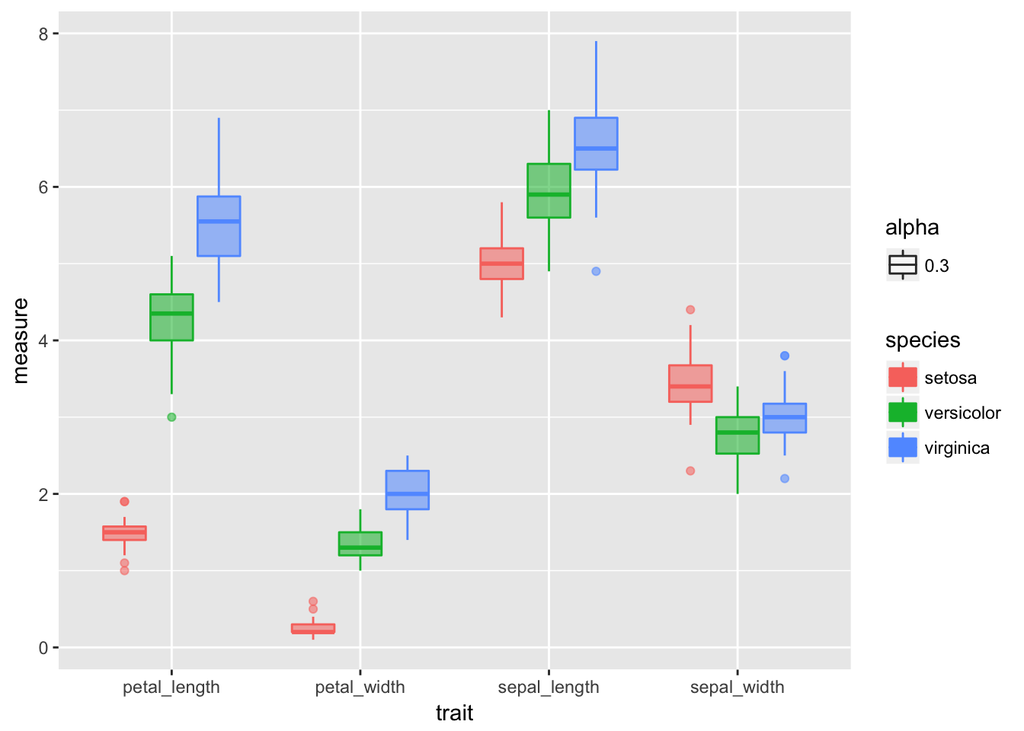

```r
# Box Plots of data
iris_long.df %>% group_by(species, trait) %>%
  ggplot( aes(x = trait, y = measure, color = species, fill=species))+
  geom_boxplot(aes(alpha=0.3))
```

These look good for the most part with only one or two significant. Your choice to transform or not.

## Factors

Make sure the categorical variable is a factor  
Rearrange the order of groups so that control group is first, followed by treatment groups.  
you can do this by:

```r
# Make Factors from the different levels long way
# iris_long.df$species <- as.factor(iris_long.df$species)
# iris_long.df$trait <- as.factor(iris_long.df$trait)

# Make Factors dplyr
iris_long.df <- iris_long.df %>%
  mutate(
   sex = factor(species,
                  labels = c("setosa", "versicolor", "virginica")),
    trait = factor(trait,
                  labels = c("sepal_length", "sepal_width", "petal_length", "petal_width"))
  )
```

When doing this with Type 1 sum of squares putting the control first is critical `data$categories <- factor(data$categories, levels=c("c","a","b","d")`

## Separate out the traits to new dataframes for analyses.

First lets subset the data into the respective traits to analyze one of them at a time

```r
# # THIS IS THE BEST WAY TO SUBSET DATAFRAMES!!!! WOW!! ----
# list2env(split(iris_long.df, iris_long.df$trait), envir = .GlobalEnv)
#
#
# # # THIS IS HOW TO DO IT WITH TREATMENTS - MAKING SEPARATE DATAFRAMES
# # t <- unique(iris_long.df$trait)
# # for (i in trait){
# #   x <- dplyr::filter(iris_long.df, trait == i)
# #   t<-paste("trait","_",i, sep="")
# #   assign(t,x)
# #   }
# # rm(x, t, i, trait)
```

## Test for normality of data and using the broom package

So I think this is premature but some people like to test the normality of the data but really you should be assessing the normality of the residuals. But here it goes…

```r
# turn off scientific notaton
options(scipen = 999)
# to turn back on
#options(scipen = 0)

# Test for normality of each group and store in shapirowilktests
# This uses the broom package to get clean output of the test
iris_long.df %>% group_by(species, trait) %>% do(tidy(shapiro.test(.$measure)))
```

[output not shown]

```r
#You can do this on all variables faster with if there was only one grouping
# tapply(iris_long.df$measure, iris_long.df$species, shapiro.test)
```

## Test for homogenetiy of variances

Best to use the Levenes test compared to the Bartlet test  
uses the car package

http://www.cookbook-r.com/Statistical_analysis/Homogeneity_of_variance/

```r
#Test for homogeneity of variances by groups
leveneTest(sepal_length ~ species, data=iris.df)
```

```
## Levene's Test for Homogeneity of Variance (center = median)
##        Df F value   Pr(>F)
## group   2  6.0386 0.003022 **
##       146
## ---
## Signif. codes:  0 '***' 0.001 '**' 0.01 '*' 0.05 '.' 0.1 ' ' 1
```

```r
#Compared to the Bartlet test
bartlett.test(sepal_length ~ species, data=iris.df)
```

```
##
##  Bartlett test of homogeneity of variances
##
## data:  sepal_length by species
## Bartlett's K-squared = 15.308, df = 2, p-value = 0.0004742
```

```r
# Bartlett test with interaction
# bartlett.test(measure ~ interaction(species,trait), data=iris.df)
```

### The ONE WAY ANOVA

```r
#Run the anova and store it in the model in Values
sepal_lenght.model.lm = lm(sepal_length ~ species, data = iris.df)

#Obtain the anova table
summary(sepal_lenght.model.lm)
```

```
##
## Call:
## lm(formula = sepal_length ~ species, data = iris.df)
##
## Residuals:
##      Min       1Q   Median       3Q      Max
## -1.68800 -0.33600 -0.00816  0.31200  1.31200
##
## Coefficients:
##                   Estimate Std. Error t value             Pr(>|t|)
## (Intercept)        5.00816    0.07378  67.878 < 0.0000000000000002 ***
## speciesversicolor  0.92784    0.10382   8.937  0.00000000000000161 ***
## speciesvirginica   1.57984    0.10382  15.217 < 0.0000000000000002 ***
## ---
## Signif. codes:  0 '***' 0.001 '**' 0.01 '*' 0.05 '.' 0.1 ' ' 1
##
## Residual standard error: 0.5165 on 146 degrees of freedom
##   (1 observation deleted due to missingness)
## Multiple R-squared:  0.6154, Adjusted R-squared:  0.6102
## F-statistic: 116.8 on 2 and 146 DF,  p-value: < 0.00000000000000022
```

```r
#Obtain the summary of the model
#This is the AOV summary
anova(sepal_lenght.model.lm)
```

```
## Analysis of Variance Table
##
## Response: sepal_length
##            Df Sum Sq Mean Sq F value                Pr(>F)
## species     2 62.328 31.1639  116.83 < 0.00000000000000022 ***
## Residuals 146 38.945  0.2667
## ---
## Signif. codes:  0 '***' 0.001 '**' 0.01 '*' 0.05 '.' 0.1 ' ' 1
```

## AOV

The anova method is also rather straight forward they give essentialy the same information

```r
#Run the anova and store it in the model in Values
sepal.length.model.aov = aov(sepal_length ~ species, data = iris.df)

#Obtain the anova table
anova(sepal.length.model.aov)
```

```
## Analysis of Variance Table
##
## Response: sepal_length
##            Df Sum Sq Mean Sq F value                Pr(>F)
## species     2 62.328 31.1639  116.83 < 0.00000000000000022 ***
## Residuals 146 38.945  0.2667
## ---
## Signif. codes:  0 '***' 0.001 '**' 0.01 '*' 0.05 '.' 0.1 ' ' 1
```

## Save Anova Table to excel

```r
tidy_sepal_length <- tidy(sepal.length.model.aov)
write_csv(tidy_sepal_length, "tidy_sepal_lenght_anova.csv")
```

### Confidence intervals of treatment parameters

https://www.r-bloggers.com/one-way-analysis-of-variance-anova/ The function confint returns confidence intervals on the treatment parameters which are by default 95% confidence intervals:  
not sure why the test requires aov and wont work on lm {#confidence}

```r
#Confidence intervals of the values
confint(sepal.length.model.aov)
```

```
##                       2.5 %   97.5 %
## (Intercept)       4.8623447 5.153982
## speciesversicolor 0.7226518 1.133022
## speciesvirginica  1.3746518 1.785022
```

### We can look at effect sizes

not sure why the test requires aov and wont work on lm {#effectsize}

```r
#Effect sizes of the variables
model.tables(sepal.length.model.aov,se=T)
```

```
## Design is unbalanced - use se.contrast() for se's
```

```
## Tables of effects
##
##  species
##      setosa versicolor virginica
##     -0.8415    0.08634    0.7383
## rep 49.0000   50.00000   50.0000
```

### You can also look at the means of the values from the AOV.

not sure why the test requires aov and wont work on lm

```r
#Means of the values from the AOV
model.tables(sepal.length.model.aov, "means", se=T)
```

```
## Design is unbalanced - use se.contrast() for se's
```

```
## Tables of means
## Grand mean
##
## 5.849664
##
##  species
##     setosa versicolor virginica
##      5.008      5.936     6.588
## rep 49.000     50.000    50.000
```

### Now to plot model residuals versus fitted values to investigate the model assumptions.

### The base R approach

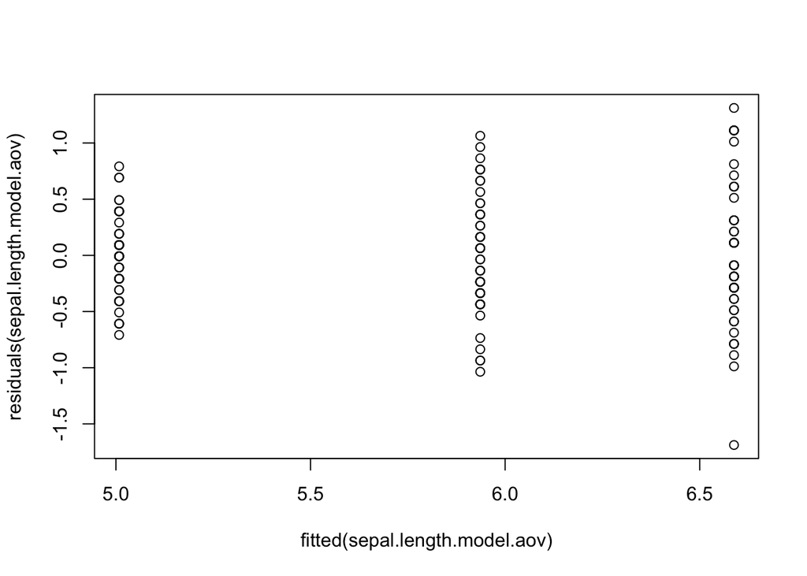

```r
#Base R plots
plot(fitted(sepal.length.model.aov), residuals(sepal.length.model.aov))
```

### Histogram of residuals

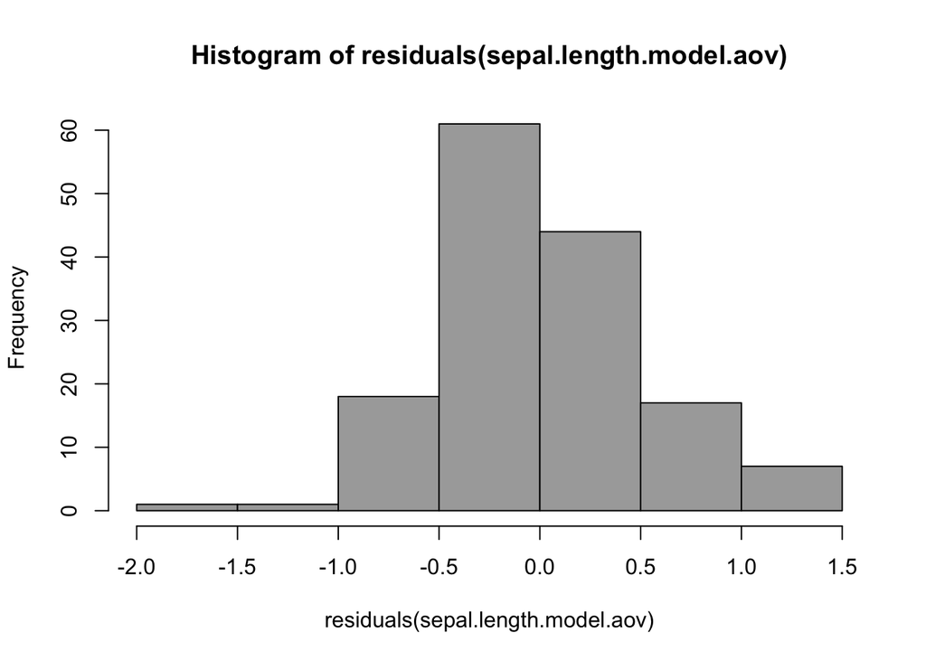

```r
#Histogram of residuals
hist(residuals(sepal.length.model.aov),
     col="darkgray")
```

### Visual check for normality of residuals

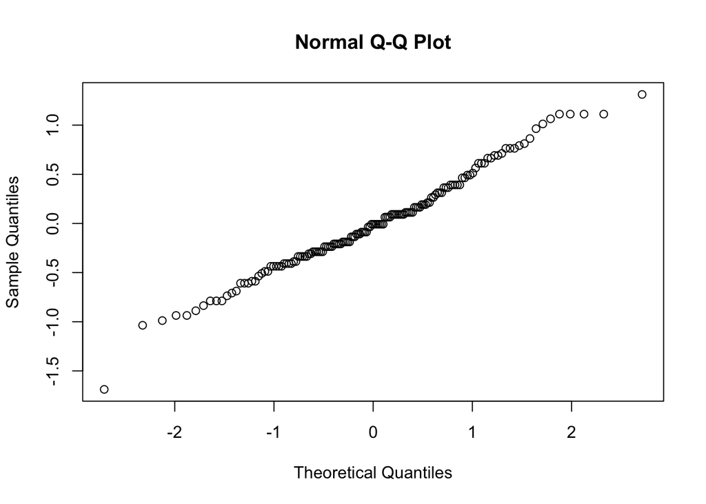

```r
# check for normally distributed data
qqnorm(sepal.length.model.aov$res)
```

### Test for normality of residuals

```r
#Test for normality of residuals
shapiro.test(sepal.length.model.aov$res)
```

```
##
##  Shapiro-Wilk normality test
##
## data:  sepal.length.model.aov$res
## W = 0.98814, p-value = 0.2368
```

### Post hoc comparisons

```r
library(lsmeans)
# Comparisons of species
lsm = lsmeans(sepal.length.model.aov,
              "species",
              adjust="bonferroni")
### Means sharing a letter in .group are not significantly different
cld(lsm,
    alpha=.05,
    Letters=letters)
```

```
##  species      lsmean         SE  df lower.CL upper.CL .group
##  setosa     5.008163 0.07378191 146 4.862345 5.153982  a
##  versicolor 5.936000 0.07304037 146 5.791647 6.080353   b
##  virginica  6.588000 0.07304037 146 6.443647 6.732353    c
##
## Confidence level used: 0.95
## P value adjustment: tukey method for comparing a family of 3 estimates
## significance level used: alpha = 0.05
```

[figure not shown]

```r
#Examine the distribution of the data for each group of Sepal.Length
iris_long.df %>% filter(trait=="sepal_length")  %>% ggplot(aes(x= species, y=measure))+
  geom_boxplot() +
  annotate("text", x="setosa", y=8, label= "A",fontface="bold", size=10 ) +
  annotate("text", x="versicolor", y=8, label= "B",fontface="bold", size=10 ) +
  annotate("text", x="virginica", y=8, label= "C", fontface="bold", size=10) +
  labs(y="Sepal Length")
```

# Now to GEEK OUT!!! We can do this on all at the same time

## HOLY MACKAREL THIS IS COOL!!! and it can save as a clean dataframe but does not save as models so it is not that helpful

```r
# WOW JUST WOW
library(broom)
iris_long.df  %>%
  group_by(trait) %>%
  do(model = aov(measure ~ species, data = .)) %>%
  glance(model) # or tidy(model) - this is to see the data in a clean way
```

[output not shown]